# Methodology

**Methodology**

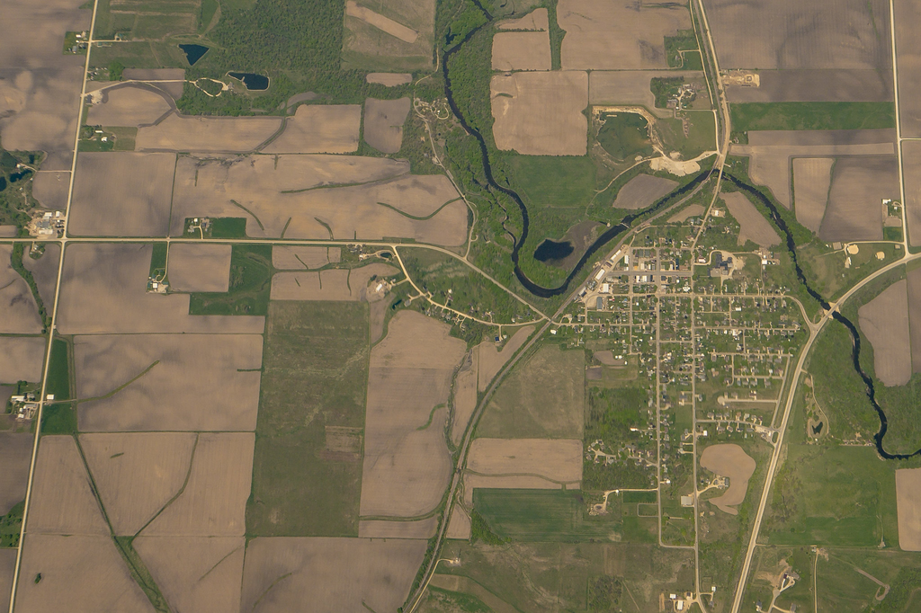

*Land Use Classification and Feed Allocation*

Land cover describes what is on the ground; land use describes how it is used. The National Land Cover Database (NLCD) provides geographic context, while MLU supplies the statewide acreage totals. Their categories require careful alignment: a pasture/hay land-cover class, for example, can include both grazed land and fields harvested for feed.

Forage crops include corn silage, hay, alfalfa, and other forage. We allocate these crops entirely to animal feed. Alfalfa is included in total hay or forage acreage when the source reports it that way, so it is not added again.

Mixed-use crops include corn grain, soybeans, oats, wheat, and sugar beets. They supply feed, food, fuel, and industrial markets. Processing can produce several outputs from the same crop, including soybean meal and oil, ethanol and distillers grains, wheat flour and middlings, or sugar and beet pulp.

Food and other nonfeed crops include fruits, vegetables, potatoes, tree nuts, and specialty crops grown primarily for human food or other uses. Nonfood crops, such as tobacco, are classified separately from food crops.

For Iowa and Minnesota, we allocate 54% of corn-grain acreage and 80% of soybean acreage to feed, using assumptions informed by USDA ERS commodity-use data. The corn share combines direct feed use with a credit for distillers grains returned to domestic feed markets after ethanol production.

The soybean share approximates the combined mass of meal and hulls from crushing. These are allocation rules, not observed destinations for each state’s harvest. Processing yields, exports, and the treatment of co-products affect the result, and the same crop acreage must not be counted in full for more than one use.

We apply feed shares to the crop classes in the USDA Cropland Data Layer (CDL), weighting each share by crop area. The result is an acreage equivalent attributed to feed, referred to here as feed-allocated cropland. Where the CDL identifies a double-crop class, its area is divided evenly between the two crops. The resulting feed estimates are approximately 16.1 million acres in Iowa and 12.1 million in Minnesota.

We use a two-layer classification system. The first describes broad land uses, using USDA Economic Research Service (ERS) Major Land Uses (MLU) acreage estimates for cropland, grassland pasture and range, forest-use land, special-use areas, urban land, and miscellaneous land. The second examines agricultural land by purpose, distinguishing crops grown for animal feed from crops serving food, fuel, and other markets.

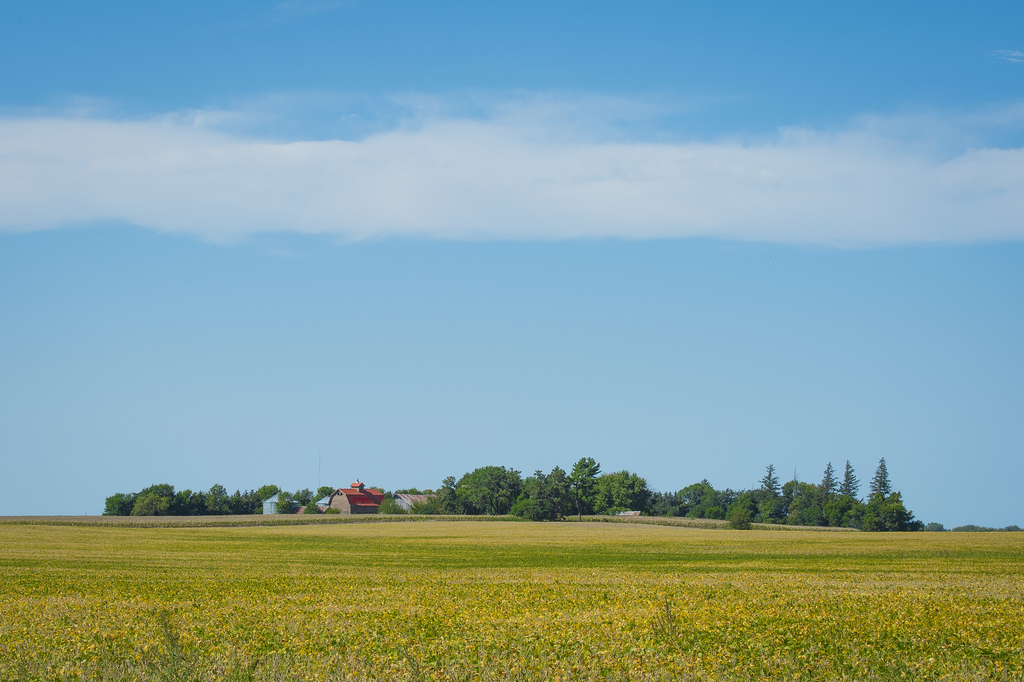

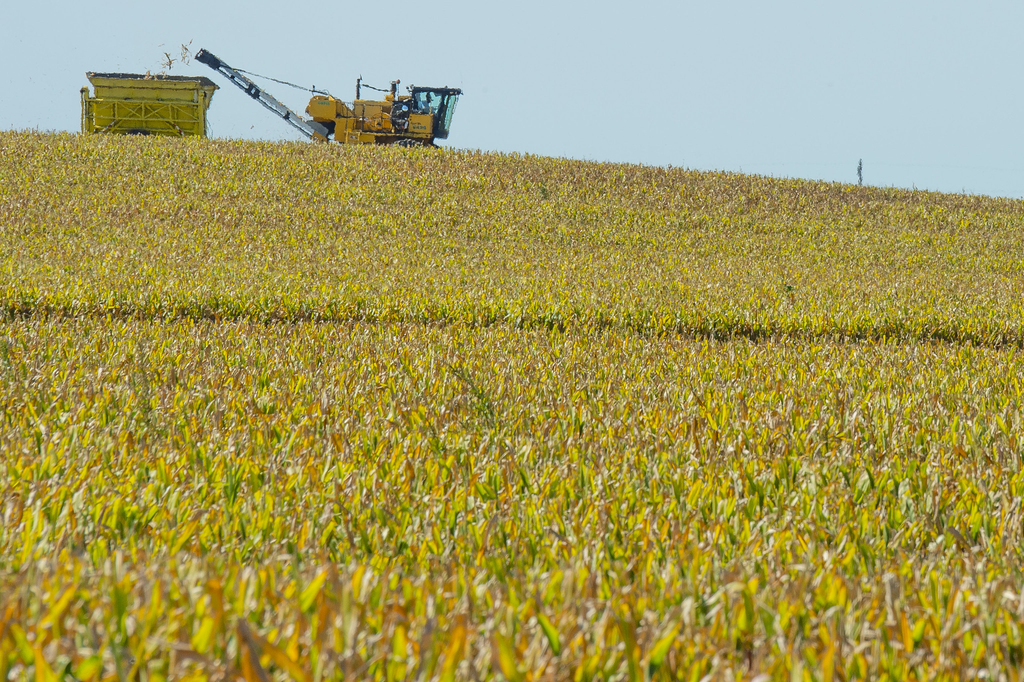

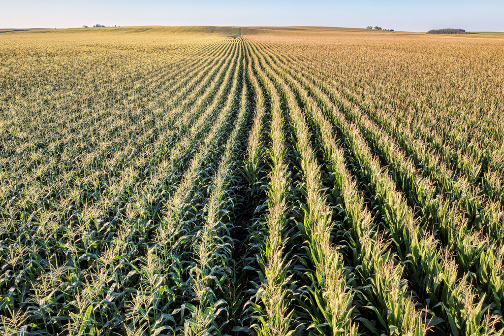

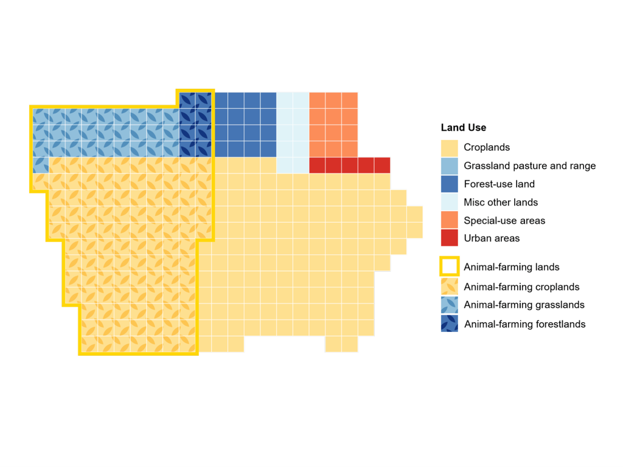

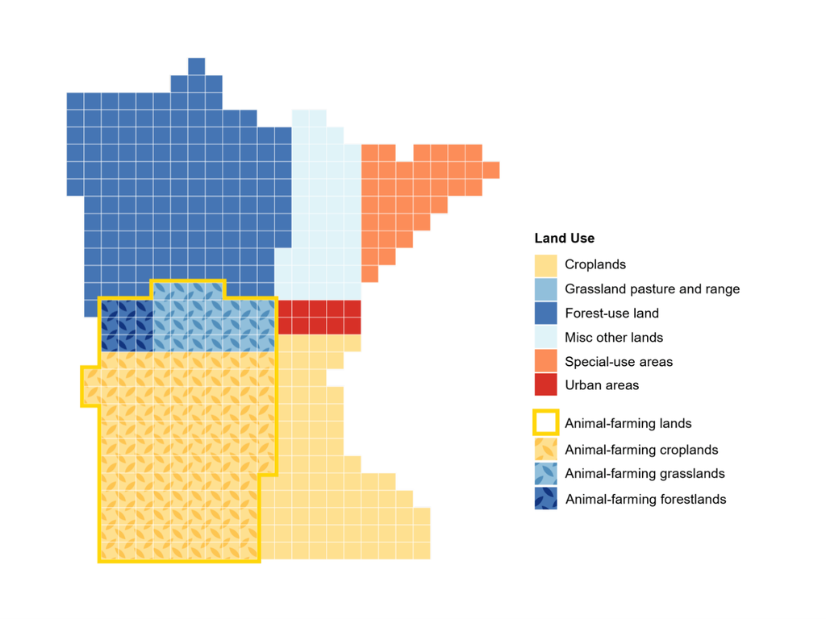

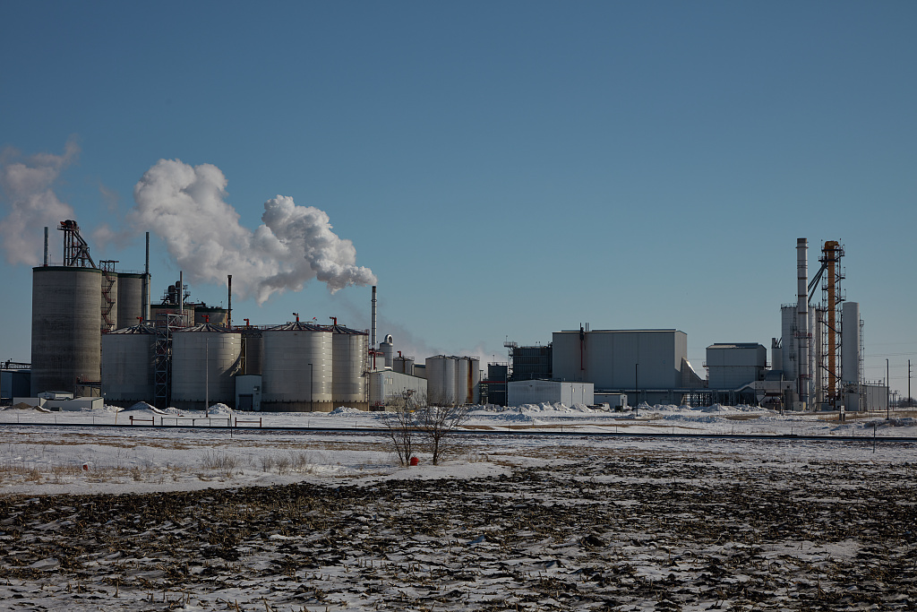

New York uses a different approach.

For New York, we use the Office of the New York State Comptroller’s 2024 agriculture profile, which reports that 33% of farmland grows animal feed. Applying that rounded share to the 2022 Census total of 6,502,286 acres in farms gives an estimated 2.15 million feed acres, or about 53% of the state’s 4,076,225 cropland acres. This is an aggregate estimate rather than a crop-by-crop allocation. The profile does not specify how much corn grain, soybeans, or other mixed-use crops contribute to that share.

Land can support more than one use. A field may produce successive crops, provide cover between harvests, or be grazed seasonally. A map that assigns one dominant use cannot capture all of these functions. Multiple-cropping research shows why harvested crop acres can differ from physical land area: growing two crops on an acre does not create a second acre of land (Waha et al., 2025).

Agrivoltaics, which combines solar generation with agricultural production, offers another example of shared land use. These arrangements can retain cropping or grazing alongside energy production, although their suitability depends on the site and design. The maps do not separately identify such overlapping uses (Daniels and Chen, 2025).

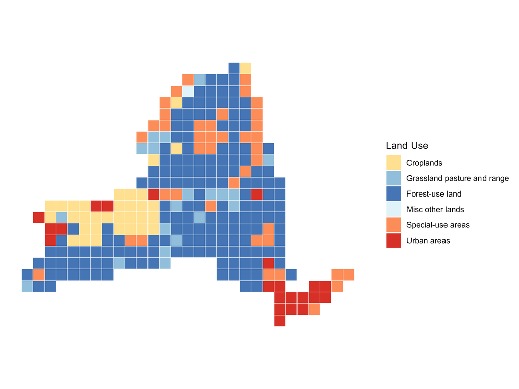

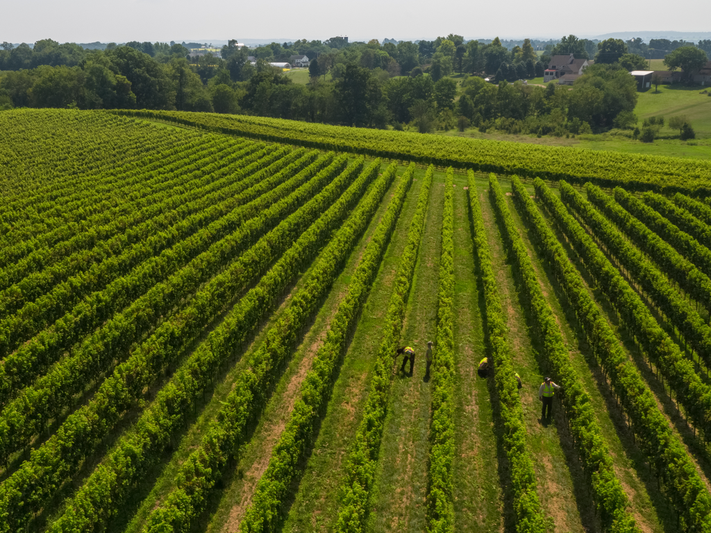

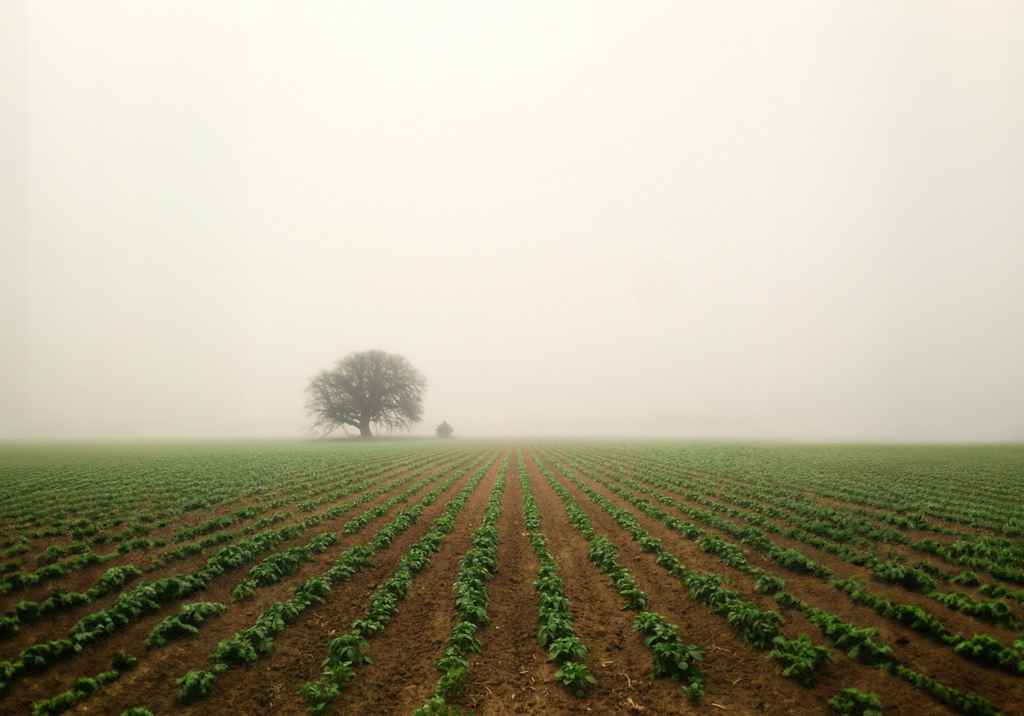

*Data Sources and Map Construction*

*County Comparisons*

The feed estimates do not use a uniform method across all three states. New York’s aggregate feed category differs from the crop-by-crop allocations for Iowa and Minnesota, limiting precise comparisons of livestock’s share of agricultural land.

The feed estimates depend on crop areas, commodity years, exports, and co-product accounting. The estimated feed acres and grazing acres must also remain separate so the same land is not counted twice.

The CDL can misclassify crops and other land cover, especially when used to infer change over time. That error can raise or lower estimated feed shares (Lark et al., 2017; Reitsma et al., 2016). The CDL’s corn class also requires a separate grain–silage split before different feed shares can be applied.

The Census of Agriculture includes permanent pasture and rangeland, cropland pasture, and woodland pastured on farms. MLU also estimates grazing land outside farms and uses different methods. Differences between the two sources therefore reflect coverage, classification, and observation year. Cropland pasture is already part of total cropland and must be subtracted when total cropland and grazing acreage are combined.

Farm counts and average acreage describe how farmland is organized. Changes in production intensity, animal housing, or the causes of land conversion require additional evidence.

The Census of Agriculture and NASS annual surveys provide crop acreage, livestock inventories, and farm-structure data. MLU supplies statewide land totals and grazing estimates. NLCD provides land-cover context, and the CDL identifies crop classes for Iowa’s and Minnesota’s feed allocations. New York draws its feed estimate from the State Comptroller’s profile of the 2022 Census.

The footprint combines the 2017 MLU land baseline with more recent crop information. It is an estimate assembled from several sources and years, rather than a single-year land inventory.

The maps retain the 2017 MLU baseline even though the series now includes 2022 observations.

The proportional maps simplify land use into tiles so readers can see the relative scale of different uses. Each tile represents a nominal 125,000 acres, but rounding and the treatment of the state boundary mean that tile counts do not reproduce exact acreage. We use the statistical source totals for all acreage and percentage calculations.

County comparisons show where livestock and feed crops occur together. We compare dairy-cow inventories with harvested corn-silage acreage; the Iowa analysis also compares hog inventories with corn-grain acreage. These relationships describe patterns among counties, not individual feed purchases or the land required by an additional animal. County size, growing conditions, farm structure, and missing observations can all affect the results.

*Limitations*